# R Basic Training

Hannah Fresques

February 4, 2015

# The Assignment

The Nigerian Government has committed $1.2 billion USD to achieving the United Nations Millennium Development Goals. Matching grants are given to Local Government Areas (LGAs) for approved projects and programmes geared towards reducing poverty and improving education and health. To promote the use of data in the local planning process, a rigorous, geo-referenced, baseline facility inventory was conducted for the entire country. The objective was to collect data for all of Nigeria’s health, education and water facilities. The result is this online portal, the Nigeria MDG Information System (NMIS) see http://nmis.mdgs.gov.ng/about.

Using this rich dataset, we will assess a few key development statistics, previously unknowable.

# Set up

Load needed packages and user defined functions.

```r
library(knitr)
library(rmarkdown)
library(plyr)
library(ggplot2)

# function to check NAs in a data frame
NAcheck <- function(data) {
  NAs <- sum(is.na(data))
  print(paste("NAs:", NAs))  # count NA's
  if (NAs > 0)
    data[which(is.na(data)), ]  # Show NA's, if any.
  cc <- complete.cases(data)  # logical for each case (row)
  print(paste("Complete Cases:", all(cc)))  # Given a set of logical values, are all TRUE?
}

# function to return string w/o leading or trailing whitespace
trim <- function (x) gsub("^\\s+|\\s+$", "", x)
```

# Question 1

Instructions: Go to this link https://github.com/Ecohen4/data-viz/blob/master/r/lgas.csv to retrieve general metadata for Local Government Areas (LGAs) of Nigeria. LGAs are akin to counties in the U.S.

## Read in and inspect the metadata file

```r
# read metadata
setwd("/Users/hfresq/github/data-viz/r")
file <- "lgas.csv"
metadata0 <- read.csv(file)
```

Inspect the metadata

```r
str(metadata0)
```

```
## 'data.frame':    774 obs. of  13 variables:
##  $ lga_id             : int  1 2 3 4 5 6 7 8 9 10 ...
##  $ unique_lga         : Factor w/ 773 levels "abia_aba_north",..: 142 275 39 211 1 2 563 564 169 292 ...
##  $ pop_2006           : int  100180 58444 139090 151723 107488 423852 201329 250278 144802 195652 ...
##  $ lga                : Factor w/ 768 levels "Aba North","Aba South",..: 3 4 5 6 1 2 7 8 9 10 ...
##  $ state              : Factor w/ 37 levels "Abia","Adamawa",..: 8 15 3 11 1 1 28 28 9 17 ...
##  $ zone               : Factor w/ 6 levels "North-Central",..: 2 1 4 5 5 5 6 6 4 5 ...
##  $ area_sq_km         : num  3967.1 992.4 190 584.1 22.8 ...
##  $ surveying_effort   : Factor w/ 4 levels "113","148","Others",..: 3 1 3 3 3 3 3 3 3 3 ...
##  $ pop_density_2006   : num  25.3 58.9 732.1 259.8 4719.5 ...
##  $ longitude          : num  13.33 6.85 7.77 8.22 7.37 ...
##  $ latitude           : num  13.43 8.88 5.02 6.26 5.11 ...
##  $ senatorial_district: Factor w/ 67 levels "","Abia Central",..: 40 1 33 21 4 4 42 42 12 53 ...
##  $ TA_names           : Factor w/ 121 levels "Abdul Samad Isah Haruna",..: 75 57 62 83 19 114 108 108 94 80 ...
```

```r
head(metadata0)
```

```
##   lga_id       unique_lga pop_2006       lga     state          zone
## 1      1     borno_abadam   100180    Abadam     Borno     Northeast
## 2      2        fct_abaji    58444     Abaji       FCT North-Central
## 3      3   akwa_ibom_abak   139090      Abak Akwa Ibom   South-South
## 4      4 ebonyi_abakaliki   151723 Abakaliki    Ebonyi     Southeast
## 5      5   abia_aba_north   107488 Aba North      Abia     Southeast
## 6      6   abia_aba_south   423852 Aba South      Abia     Southeast
##   area_sq_km surveying_effort pop_density_2006 longitude latitude
## 1    3967.05           Others            25.25    13.326   13.428
## 2     992.36              113            58.89     6.853    8.878
## 3     189.98           Others           732.11     7.772    5.020
## 4     584.06           Others           259.78     8.220    6.259
## 5      22.78           Others          4719.55     7.372    5.107
## 6      49.17           Others          8620.74     7.351    5.081
##   senatorial_district                       TA_names
## 1               North               Mukhtar Abubakar
## 2                                      Ipah Iloye A.
## 3         Ikot Ekpene                    Jesse Akpan
## 4        Ebonyi North             Obasi Arisi Ikenna
## 5          Abia South Anichukwueze Anthony Nkemdirim
## 6          Abia South          Ujah Chukwudu Francis
```

## Conduct data QC and cleaning on metadata file

Start by checking for missing values in the metadata.

```r
NAcheck(metadata0) # check missings in metadata using the NAcheck function.
```

```
## [1] "NAs: 5"
## [1] "Complete Cases: FALSE"
```

```r
metadata0[which(is.na(metadata0)), ]  # Show NA's, if any. Not sure why these didn't print using the NAcheck function...
```

```
##      lga_id unique_lga pop_2006  lga state zone area_sq_km
## NA       NA       <NA>       NA <NA>  <NA> <NA>         NA
## NA.1     NA       <NA>       NA <NA>  <NA> <NA>         NA
## NA.2     NA       <NA>       NA <NA>  <NA> <NA>         NA
## NA.3     NA       <NA>       NA <NA>  <NA> <NA>         NA
## NA.4     NA       <NA>       NA <NA>  <NA> <NA>         NA
##      surveying_effort pop_density_2006 longitude latitude
## NA               <NA>               NA        NA       NA
## NA.1             <NA>               NA        NA       NA
## NA.2             <NA>               NA        NA       NA
## NA.3             <NA>               NA        NA       NA
## NA.4             <NA>               NA        NA       NA
##      senatorial_district TA_names
## NA                  <NA>     <NA>
## NA.1                <NA>     <NA>
## NA.2                <NA>     <NA>
## NA.3                <NA>     <NA>
## NA.4                <NA>     <NA>
```

There are several completely empty rows. These serve no prupose, so I’ll remove them.

```r
metadata0 <- na.omit(metadata0) # 5 rows with NA in all fields. Omit NAs
nrow(metadata0) # confirm that five rows were removed.
```

```
## [1] 769
```

Later in the data processing, I’ll use unique_lga to merge the metadata file with another file. With that in mind, here are some additional checks on the unique_lga field.

It’s important for the merge that unique_lga is infact unique on the metadata file.

```r
chk1 <- data.frame(table(metadata0$unique_lga, useNA="always")) # create a dataframe to use to check for duplicates
chk1 <- rename(chk1, c("Var1"="unique_lga"))
chk1[chk1$Freq > 1,] # print all values of unique_lga which occur more than once in the metadata file.
```

```
##      unique_lga Freq
## 371 kano_bagwai    2
```

It appears there is a duplicate LGA in the metadata file. Below, I look at it in more detail.

```r
metadata0[metadata0$unique_lga == "kano_bagwai",] # look more closely at all obs of the duplicate LGA
```

```
##    lga_id  unique_lga pop_2006    lga state      zone area_sq_km
## 82     82 kano_bagwai   162847 Bagwai  Kano Northwest        405
## 83     82 kano_bagwai   162847 Bagwai  Kano Northwest        405
##    surveying_effort pop_density_2006 longitude latitude
## 82              148            402.1     8.141     12.1
## 83              148            402.1     8.141     12.1
##    senatorial_district                 TA_names
## 82            Northern Maimuna Mohammed Dalhatu
## 83            Northern Maimuna Mohammed Dalhatu
```

```r
nrow(metadata0) # num rows before removing duplicate
```

```
## [1] 769
```

```r
metadata <- unique(metadata0) # remove the duplicate
nrow(metadata) # num rows after removing duplicate
```

```
## [1] 768
```

Once the duplicate row was removed, we’re left with a clean file containing 768 unique LGAs. According to Wikipedia, there are 774 local government areas (LGAs) in Nigeria, which matches the number of obs on the original metadata file. However, the rows removed do not contain any useful information on the missing 6 LGAs (774-768=6).

# Identify Southern zones

Later we want to subset the data for analysis to look at only LGAs in southern zones. Create a variable now to make those LGAs easy to identify.

```r
metadata$south <- ifelse(metadata$zone %in% c("South-South", "Southeast", "Southwest"), TRUE, FALSE)
table(metadata$zone, metadata$south, useNA = "always") # confirm south assigned as expected
```

```
##
##                 FALSE TRUE <NA>
##   North-Central   121    0    0
##   Northeast       112    0    0
##   Northwest       184    0    0
##   South-South       0  122    0
##   Southeast         0   93    0
##   Southwest         0  136    0
##   <NA>              0    0    0
```

# Question 2

Instructions: Next, download the full NMIS dataset http://nmis.mdgs.gov.ng/download, and grab the [large] .csv file called “Health_Mopup_and_Baseline_NMIS_Facility.csv”. This contains every health facility in Nigeria.

## Read in the full file of all health clinics

```r
# read full file
setwd("/Users/hfresq/github/data-viz/r/nmis_dataset")
file <- "Health_Mopup_and_Baseline_NMIS_Facility.csv"
fulldata0 <- read.csv(file)
```

## Inspect and QC the full file

```r
str(fulldata0) # inspect full file
```

```
## 'data.frame':    34139 obs. of  30 variables:
##  $ facility_name                    : Factor w/ 28550 levels "\nModel pry healthcare",..: 10496 1224 23082 20322 10286 26394 10563 27789 14315 16562 ...
##  $ facility_type_display            : Factor w/ 18 levels "Basic Health Centre / Primary Health Clinic",..: 9 14 1 14 9 9 9 16 16 9 ...
##  $ maternal_health_delivery_services: logi  TRUE TRUE TRUE TRUE TRUE TRUE ...
##  $ emergency_transport              : logi  TRUE TRUE TRUE FALSE FALSE TRUE ...
##  $ skilled_birth_attendant          : logi  FALSE TRUE TRUE FALSE FALSE TRUE ...
##  $ num_chews_fulltime               : int  1 4 2 2 0 0 0 1 4 1 ...
##  $ phcn_electricity                 : logi  TRUE TRUE TRUE FALSE FALSE FALSE ...
##  $ c_section_yn                     : logi  FALSE FALSE TRUE FALSE FALSE TRUE ...
##  $ child_health_measles_immun_calc  : logi  TRUE TRUE TRUE TRUE TRUE FALSE ...
##  $ num_nurses_fulltime              : int  0 1 4 0 0 2 1 6 NA 0 ...
##  $ num_nursemidwives_fulltime       : int  0 1 11 0 0 0 0 12 4 0 ...
##  $ num_doctors_fulltime             : int  0 1 2 0 0 1 0 5 15 0 ...
##  $ date_of_survey                   : Factor w/ 323 levels "2009-07-23","2010-10-20",..: 240 273 249 242 242 244 240 241 241 262 ...
##  $ facility_id                      : Factor w/ 34122 levels "AAABW","AAADE",..: 28724 10619 10978 16657 17973 17419 13808 10914 12589 15203 ...
```

[output cut: 16 more lines]

```r
NAcheck(fulldata0) # check for NAs
```

```
## [1] "NAs: 34563"
## [1] "Complete Cases: FALSE"
```

There are many NA values. There is no reason that they’re of particular concern.

Check the unique_lga field on the full data. It is important that unique_lga is non-missing for all obs. Duplicates on unique_lga are expected

```r
nrow(fulldata0[is.na(fulldata0$unique_lga),]) # return number of rows with missing unique_lga
```

```
## [1] 0
```

Check for exact duplicates on the full data. (Exact duplicates are cases where all columns match exactly.)

```r
dup_ids <- unique(fulldata0[duplicated(fulldata0), "facility_id"]) # Create a list of facility ids which have exact duplicate rows
# Show all instances of duplicates, including the first instance.
# (Code ommitted because output is long.)
# fulldata0[fulldata0$facility_id %in% dup_ids, ]
```

There are many exact duplicates on the data. I don’t notice anything to justify keeping the duplicates since they are all are exact duplicates. I’ll drop them.

```r
nrow(fulldata0) # number of rows on full data before dropping duplicates
```

```
## [1] 34139
```

```r
fulldata <- unique(fulldata0) # drop exact duplicates
nrow(fulldata) # number of rows on full data after dropping duplicates
```

```
## [1] 34122
```

# Question 3

Instructions: Produce a new data.frame with the following properties: - From the NMIS Health Facilities Inventory, select all facilities located in the Southern zones of Nigeria. - Incorporate LGA metadata into this new dataframe.

# Inspect the datasets and prepare for the merge

```r
dim(fulldata) # Check the number of rows and columns on full data
```

```
## [1] 34122    30
```

```r
dim(metadata) # Check the number of rows and columns on meta data
```

```
## [1] 768  14
```

```r
# Create variables to help check the merge later
fulldata$fromFULL <- TRUE
metadata$fromMETA <- TRUE
```

From past attempts at merging the data using unique_lga, I’ve learned that there are a handfull of spelling inconsistencies between the metadata and full data files. I’ll make some hardcoded edits to the unique_lga field on the metadata file so that it matches the full data file.

```r
# make some hardcoded edits to the unique_lga field to facilitate matching
# remove leading and trailing white splaces from unique_lga on both dataframes.
fulldata$unique_lga <- trim(fulldata$unique_lga)
metadata$unique_lga <- trim(metadata$unique_lga)
# Make changes to the metadata so that it matches values seen on the fulldata
newfromfull <- c("abia_obi_ngwa", "abia_umunneochi",    "adamawa_lamurde",  "adamawa_madagali", "akwa_ibom_nsit_ubium", "anambra_onitsha",  "bauchi_dambam",    "bayelsa_kolokuma_opokuma", "cross_river_bakassi",  "edo_igueben",  "edo_orhionmwon",   "enugu_nkanu_east", "gombe_yamaltu_deba",   "imo_onuimo",   "jigawa_malam_madori",  "jigawa_sule_tankarkar",    "kano_dawakin_tofa",    "kogi_olamaboro",   "niger_munya",  "ogun_yewa_north",  "ogun_yewa_south",  "oyo_oyo", "plateau_langtang_north",    "rivers_ogu_bolo",  "rivers_omumma",    "sokoto_goronyo",   "sokoto_wamako",    "taraba_karim_lamido")
levels(metadata$unique_lga) <- c(levels(metadata$unique_lga), newfromfull)
# hardcode the edits
metadata$unique_lga[metadata$unique_lga == "abia_obi_nwa"] <- "abia_obi_ngwa"
metadata$unique_lga[metadata$unique_lga == "abia_umu_neochi"] <- "abia_umunneochi"
metadata$unique_lga[metadata$unique_lga == "adamawa_larmurde"] <- "adamawa_lamurde"
metadata$unique_lga[metadata$unique_lga == "adamawa_madgali"] <- "adamawa_madagali"
metadata$unique_lga[metadata$unique_lga == "akwa_ibom_nsit_ubuim"] <- "akwa_ibom_nsit_ubium"
metadata$unique_lga[metadata$unique_lga == "bauchi_damban"] <- "bauchi_dambam"
metadata$unique_lga[metadata$unique_lga == "bayelsa_kolokuma"] <- "bayelsa_kolokuma_opokuma"
metadata$unique_lga[metadata$unique_lga == "edo_iguegben"] <- "edo_igueben"
metadata$unique_lga[metadata$unique_lga == "edo_ohionmwon"] <- "edo_orhionmwon"
metadata$unique_lga[metadata$unique_lga == "gombe_yalmatu_deba"] <- "gombe_yamaltu_deba"
metadata$unique_lga[metadata$unique_lga == "imo_unuimo"] <- "imo_onuimo"
metadata$unique_lga[metadata$unique_lga == "jigawa_malam_maduri"] <- "jigawa_malam_madori"
metadata$unique_lga[metadata$unique_lga == "jigawa_sule_tankakar"] <- "jigawa_sule_tankarkar"
metadata$unique_lga[metadata$unique_lga == "kogi_olamabolo"] <- "kogi_olamaboro"
metadata$unique_lga[metadata$unique_lga == "niger_moya"] <- "niger_munya"
metadata$unique_lga[metadata$unique_lga == "ogun_egbado_north"] <- "ogun_yewa_north"
metadata$unique_lga[metadata$unique_lga == "ogun_egbado_south"] <- "ogun_yewa_south"
metadata$unique_lga[metadata$unique_lga == "plateau_langtan_north"] <- "plateau_langtang_north"
metadata$unique_lga[metadata$unique_lga == "rivers_ogo_bolo"] <- "rivers_ogu_bolo"
metadata$unique_lga[metadata$unique_lga == "rivers_omuma"] <- "rivers_omumma"
metadata$unique_lga[metadata$unique_lga == "sokoto_wammako"] <- "sokoto_wamako"
metadata$unique_lga[metadata$unique_lga == "taraba_karin_lamido"] <- "taraba_karim_lamido"
```

# Merge the data

```r
data0 <- merge(fulldata, metadata, by = "unique_lga", all=TRUE) # using the all=True option is equivalent to outer join
```

Check the merge

```r
table(data0$fromFULL, data0$fromMETA, useNA="always")
```

```
##
##         TRUE  <NA>
##   TRUE 33914   208
##   <NA>     2     0
```

The above table shows that there were some LGAs on each dataset which did not find a match.

Look at unmatched LGAs for any hints as to why they didn’t find a match.

```r
# look at remaining unmatched LGAs from each dataset.
unique(data0[xor(is.na(data0$fromFULL), is.na(data0$fromMETA)), c("fromFULL", "fromMETA", "unique_lga")])
```

```
##       fromFULL fromMETA          unique_lga
## 3251      TRUE       NA     anambra_onitsha
## 6292        NA     TRUE        borno_abadam
## 6481        NA     TRUE         borno_gwoza
## 6887      TRUE       NA cross_river_bakassi
## 10847     TRUE       NA    enugu_nkanu_east
## 15394     TRUE       NA   kano_dawakin_tofa
## 29276     TRUE       NA             oyo_oyo
## 31470     TRUE       NA      sokoto_goronyo
```

I can’t think of anything else to do to fill in the missing information with the data available.

```r
# save a list of unmatched unique_lga values into a list to use later
unmatched <- unique(data0[xor(is.na(data0$fromFULL), is.na(data0$fromMETA)), "unique_lga"])
```

Drop all obs that were not found on both the metadata and fulldata files.

```r
dim(data0) # look at number of rows and columns before dropping unmatched observations
```

```
## [1] 34124    45
```

```r
data <- data0[which(data0$fromFULL==TRUE & data0$fromMETA==TRUE),]
dim(data) # look at number of rows and columns after dropping unmatched observations
```

```
## [1] 33914    45
```

# Subset the merged data to only the south zones

```r
table(data$south) # look at counts by south/not south before subsetting
```

```
##
## FALSE  TRUE
## 19461 14453
```

```r
data <- subset(data, data$south == TRUE) # only keep south zones
dim(data) # look at number of rows and columns after subsetting to only the south
```

```
## [1] 14453    45
```

# Question 4

Instructions: Calculate the total number of full time nurses and doctors for all health facilities, by state. Compute per capita and per area values, as well. Sort the resulting dataset by state population, in descending order. Show the results!

## Conduct additional data checks and transformation

We want to calculate state-level population and area statistics. Before doing so, let’s do a few additional data checks.

For these checks, I’ll use the cleaned, untransformed metadata file. For the checks and subsequent data processing, I’m going to subset the metadata file to exclude the handfull of LGAs which were on the metadata but which didn’t have a match on the full clinics dataset.

```r
dim(metadata) # look at number of rows and columns after subsetting to remove unmatched LGAs
```

```
## [1] 768  15
```

```r
metadata2 <- subset(metadata, !(unique_lga %in% unmatched)) # only keep south zones
dim(metadata2) # look at number of rows and columns after subsetting to remove unmatched LGAs
```

```
## [1] 766  15
```

Now, I’ll do some reasonable-ness checks on the LGA-level measures of population and area. Are there any unreasonable values?

```r
summary(metadata2$pop_2006)
```

```
##    Min. 1st Qu.  Median    Mean 3rd Qu.    Max.
##   11800  120000  157000  181000  211000 1280000
```

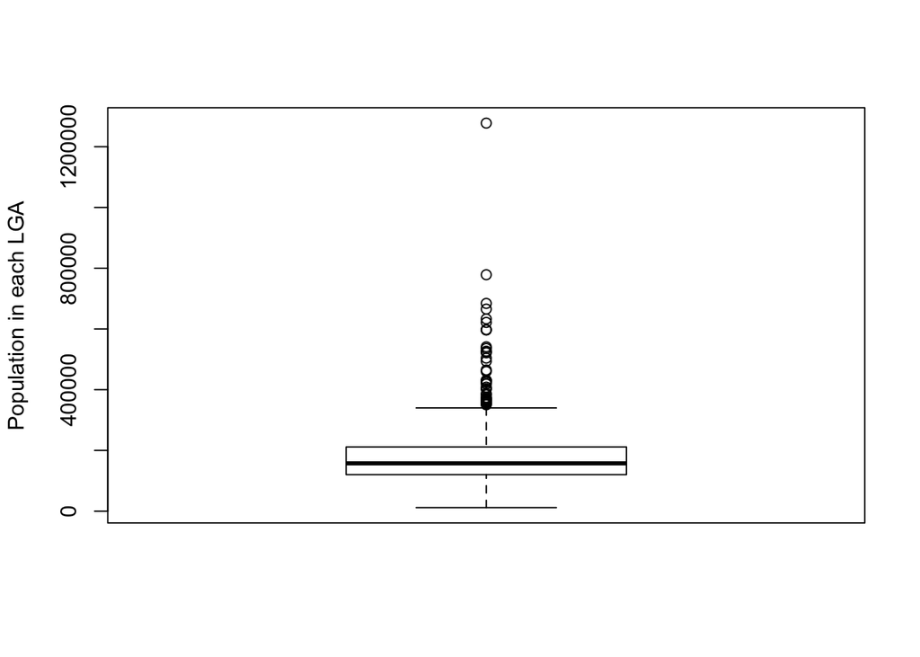

```r
boxplot(metadata2$pop_2006, ylab="Population in each LGA")
```

There is one big outlier on population, however, this could be explained by a big city. I am chosing to leave the data as-is. Additional data vaildiation is possible by looking up online population statistics for outliers. I have chosen not to pursue that at this time.

```r
summary(metadata2$area_sq_km)
```

```
##    Min. 1st Qu.  Median    Mean 3rd Qu.    Max.
##       9     282     710    1180    1470   11300
```

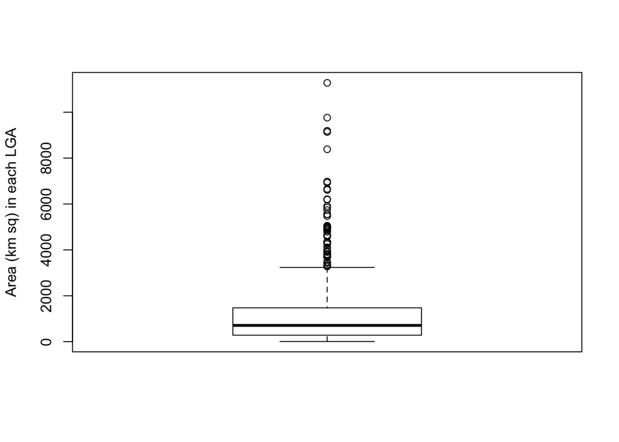

```r
boxplot(metadata2$area_sq_km, ylab="Area (km sq) in each LGA")
```

None of the values on area look problematic to me.

Next, let’s do some reasonable-ness checks on national-level statistics. We’ll still use the cleaned metadata file.

```r
print(paste("total national population in the untransformed metadata: ", formatC(sum(metadata2$pop_2006), format="d", big.mark=',')))
```

```
## [1] "total national population in the untransformed metadata:  138,779,555"
```

Total national population in 2006 was 143.3 million according to Google. This is close enough to feel confident there are no major errors in the data structure.

```r
print(paste("total national area in the untransformed metadata: ", formatC(sum(metadata2$area_sq_km), format="d", big.mark=',')))
```

```
## [1] "total national area in the untransformed metadata:  900,729"
```

Total national area is 923,768 km sq according to Google. This is close enough to feel confident there are no major errors in the data structure.

Now, using the cleaned metadata file, we’ll create a state-level dataframe with state-level population and area.

```r
state1 <- ddply(metadata2, "state", function(df)c(sum(df$pop_2006),sum(df$area_sq_km),max(df$south)))
state1 <- rename(state1, c("V1"="state_pop_2006", "V2"="state_area_sq_km", "V3"="south"))
```

Check national population and area, to ensure data was transformed as expected. Should match national statistics from above.

```r
print(paste("total national population in the transformed state1 dataset: ", formatC(sum(state1$state_pop_2006), format="d", big.mark=',')))
```

```
## [1] "total national population in the transformed state1 dataset:  138,779,555"
```

```r
print(paste("total national area in the transformed state1 dataset: ", formatC(sum(state1$state_area_sq_km), format="d", big.mark=',')))
```

```
## [1] "total national area in the transformed state1 dataset:  900,729"
```

Subset the state1 dataframe to only keep south zones.

```r
dim(state1) # number of rows and columns before limiting to south zones
```

```
## [1] 37  4
```

```r
state1 <- subset(state1, state1$south == TRUE) # only keep south zones
dim(state1) # number of rows and columns after limiting to south zones
```

```
## [1] 17  4
```

Look at the transformed, subsetted data.

```r
head(state1)
```

```
##          state state_pop_2006 state_area_sq_km south
## 1         Abia        2833999             4857     1
## 3    Akwa Ibom        3920208             6721     1
## 4      Anambra        4045370             4752     1
## 6      Bayelsa        1703358             9368     1
## 9  Cross River        2856581            20937     1
## 10       Delta        4098391            17106     1
```

Next, use the full merged data to calculate the number of doctors and nurses per state. Remember, the full merged data has already been limited to only southern states.

I’ll start by doing a few checks on the number of doctors and nurses on the untransformed file. Are there any unreasonable values?

```r
summary(data$num_nurses_fulltime)
```

```
##    Min. 1st Qu.  Median    Mean 3rd Qu.    Max.    NA's
##     0.0     0.0     0.0     1.5     2.0   513.0    1204
```

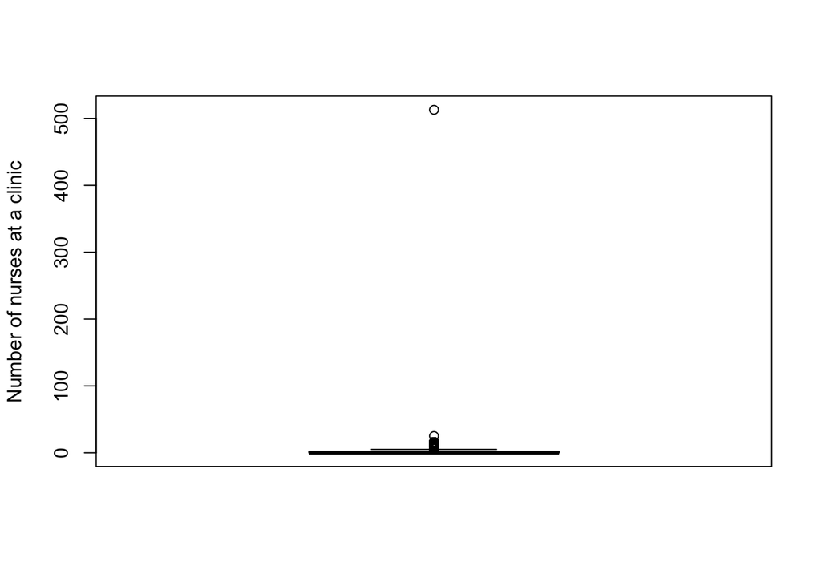

```r
boxplot(data$num_nurses_fulltime, ylab="Number of nurses at a clinic")
```

```r
summary(data$num_doctors_fulltime)
```

```
##    Min. 1st Qu.  Median    Mean 3rd Qu.    Max.    NA's
##       0       0       0       1       1     378    1097
```

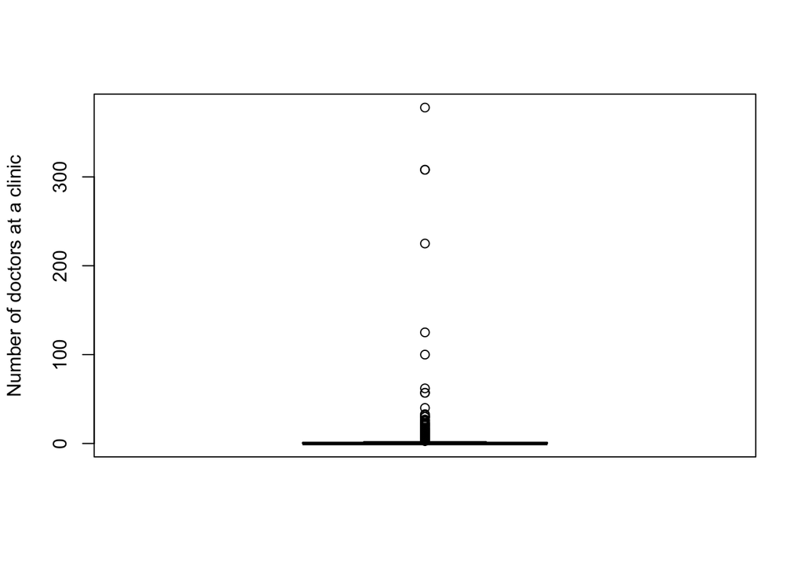

```r
boxplot(data$num_doctors_fulltime, ylab="Number of doctors at a clinic")
```

There are certainly some clinics which are outliers in terms of the number of doctors or nurses they report having. I see no obvious reason why this data cannot be correct, so I’m chosing to leave it. With more time, I might look up the specific clinics with outliers to see if I can find any way to validate the data.

Now, calculate the total number of doctors and nurses on the untransformed file, so that we can check the transformation later.

```r
print(paste("total number of nurses in the South, from the full, untransformed dataset: ", formatC(sum(data$num_nurses_fulltime, na.rm = TRUE), format="d", big.mark=',')))
```

```
## [1] "total number of nurses in the South, from the full, untransformed dataset:  20,452"
```

```r
print(paste("total number of doctors in the South, from the full, untransformed dataset: ", formatC(sum(data$num_doctors_fulltime, na.rm = TRUE), format="d", big.mark=',')))
```

```
## [1] "total number of doctors in the South, from the full, untransformed dataset:  12,878"
```

Now, use the full (merged) data to create a state-level dataframe with the total number of doctors and nurses per state.

```r
## use the full (merged) data to calculate num DRs and RNs per state
state2 <- ddply(data, "state", function(df)c(sum(df$num_nurses_fulltime, na.rm = TRUE), sum(df$num_doctors_fulltime, na.rm = TRUE)))
state2 <- rename(state2, c("V1"="num_nurses_fulltime", "V2"="num_doctors_fulltime"))
```

Check data structure of new state-level file.

```r
str(state2)
```

```
## 'data.frame':    17 obs. of  3 variables:
##  $ state               : Factor w/ 37 levels "Abia","Adamawa",..: 1 3 4 6 9 10 11 12 13 14 ...
##  $ num_nurses_fulltime : int  849 653 1600 237 903 1183 472 1045 611 1127 ...
##  $ num_doctors_fulltime: int  910 269 661 144 321 669 234 919 529 584 ...
```

```r
head(state2)
```

```
##         state num_nurses_fulltime num_doctors_fulltime
## 1        Abia                 849                  910
## 2   Akwa Ibom                 653                  269
## 3     Anambra                1600                  661
## 4     Bayelsa                 237                  144
## 5 Cross River                 903                  321
## 6       Delta                1183                  669
```

Check national-level doctor and nurse counts, to ensure data was transformed as expected. Should match national statistics from above.

```r
print(paste("total number of nurses in the South, from the transformed state2 dataset: ", formatC(sum(state2$num_nurses_fulltime, na.rm = TRUE), format="d", big.mark=',')))
```

```
## [1] "total number of nurses in the South, from the transformed state2 dataset:  20,452"
```

```r
print(paste("total number of doctors in the South, from the transformed state2 dataset: ", formatC(sum(state2$num_doctors_fulltime, na.rm = TRUE), format="d", big.mark=',')))
```

```
## [1] "total number of doctors in the South, from the transformed state2 dataset:  12,878"
```

Next, merge the two state-level datasets to get all desired fields on one dataframe.

```r
dim(state1) # dim of state1 pre merge
```

```
## [1] 17  4
```

```r
dim(state2) # dim of state2 pre merge
```

```
## [1] 17  3
```

```r
state <- merge(state1, state2, by = "state") ## merge the two state datasets
dim(state) # dim of merged state-level dataframe
```

```
## [1] 17  6
```

```r
head(state) # look at merged state-level dataframe
```

```
##         state state_pop_2006 state_area_sq_km south num_nurses_fulltime
## 1        Abia        2833999             4857     1                 849
## 2   Akwa Ibom        3920208             6721     1                 653
## 3     Anambra        4045370             4752     1                1600
## 4     Bayelsa        1703358             9368     1                 237
## 5 Cross River        2856581            20937     1                 903
## 6       Delta        4098391            17106     1                1183
##   num_doctors_fulltime
## 1                  910
## 2                  269
## 3                  661
## 4                  144
## 5                  321
## 6                  669
```

## Calculate numbers of doctors and nurses percapita and per square kilometer

```r
state$nurses_pp <- state$num_nurses_fulltime/state$state_pop_2006
state$nurses_psk <- state$num_nurses_fulltime/state$state_area_sq_km
state$doctors_pp <- state$num_doctors_fulltime/state$state_pop_2006
state$doctors_psk <- state$num_doctors_fulltime/state$state_area_sq_km

head(state) # check the new variables created by looking at a few rows
```

```
##         state state_pop_2006 state_area_sq_km south num_nurses_fulltime
## 1        Abia        2833999             4857     1                 849
## 2   Akwa Ibom        3920208             6721     1                 653
## 3     Anambra        4045370             4752     1                1600
## 4     Bayelsa        1703358             9368     1                 237
## 5 Cross River        2856581            20937     1                 903
## 6       Delta        4098391            17106     1                1183
##   num_doctors_fulltime nurses_pp nurses_psk doctors_pp doctors_psk
## 1                  910 0.0002996    0.17478  3.211e-04     0.18734
## 2                  269 0.0001666    0.09716  6.862e-05     0.04003
## 3                  661 0.0003955    0.33669  1.634e-04     0.13909
## 4                  144 0.0001391    0.02530  8.454e-05     0.01537
## 5                  321 0.0003161    0.04313  1.124e-04     0.01533
## 6                  669 0.0002886    0.06916  1.632e-04     0.03911
```

## Sort the resulting dataset by state population, in descending order.

```r
sort1.state <- state[order(-state$state_pop_2006) , ] # sort the data
head(sort1.state) # check that data sorted correctly by looking at a few rows
```

```
##      state state_pop_2006 state_area_sq_km south num_nurses_fulltime
## 12   Lagos        9013534             3480     1                3154
## 16     Oyo        5455353            27374     1                1554
## 17  Rivers        5185400            10364     1                1108
## 6    Delta        4098391            17106     1                1183
## 3  Anambra        4045370             4752     1                1600
## 11     Imo        3934899             5136     1                2137
##    num_doctors_fulltime nurses_pp nurses_psk doctors_pp doctors_psk
## 12                 2884 0.0003499    0.90640  0.0003200     0.82880
## 16                  995 0.0002849    0.05677  0.0001824     0.03635
## 17                  698 0.0002137    0.10691  0.0001346     0.06735
## 6                   669 0.0002886    0.06916  0.0001632     0.03911
## 3                   661 0.0003955    0.33669  0.0001634     0.13909
## 11                  962 0.0005431    0.41608  0.0002445     0.18730
```

## Show the results!

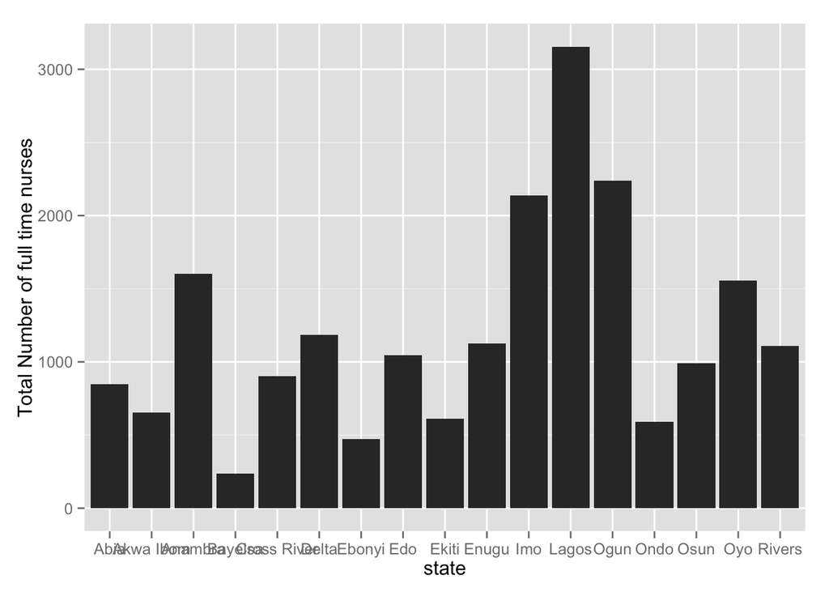

```r
ggplot(data=sort1.state, aes(x=state, y=num_nurses_fulltime)) + ylab("Total Number of full time nurses") + geom_bar(stat="identity")
```

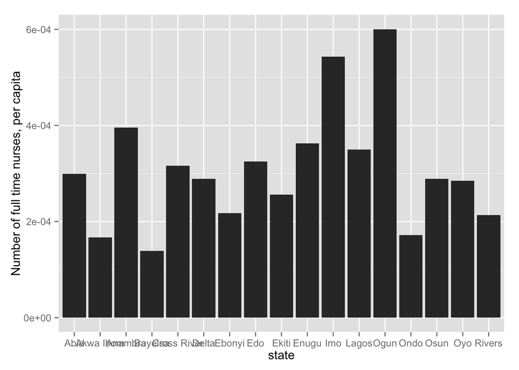

```r
ggplot(data=sort1.state, aes(x=state, y=nurses_pp)) + ylab("Number of full time nurses, per capita") + geom_bar(stat="identity")
```

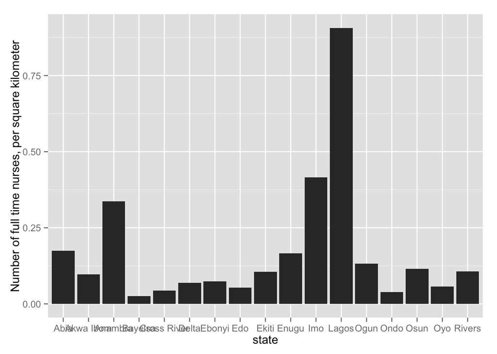

```r
ggplot(data=sort1.state, aes(x=state, y=nurses_psk)) + ylab("Number of full time nurses, per square kilometer") + geom_bar(stat="identity")
```

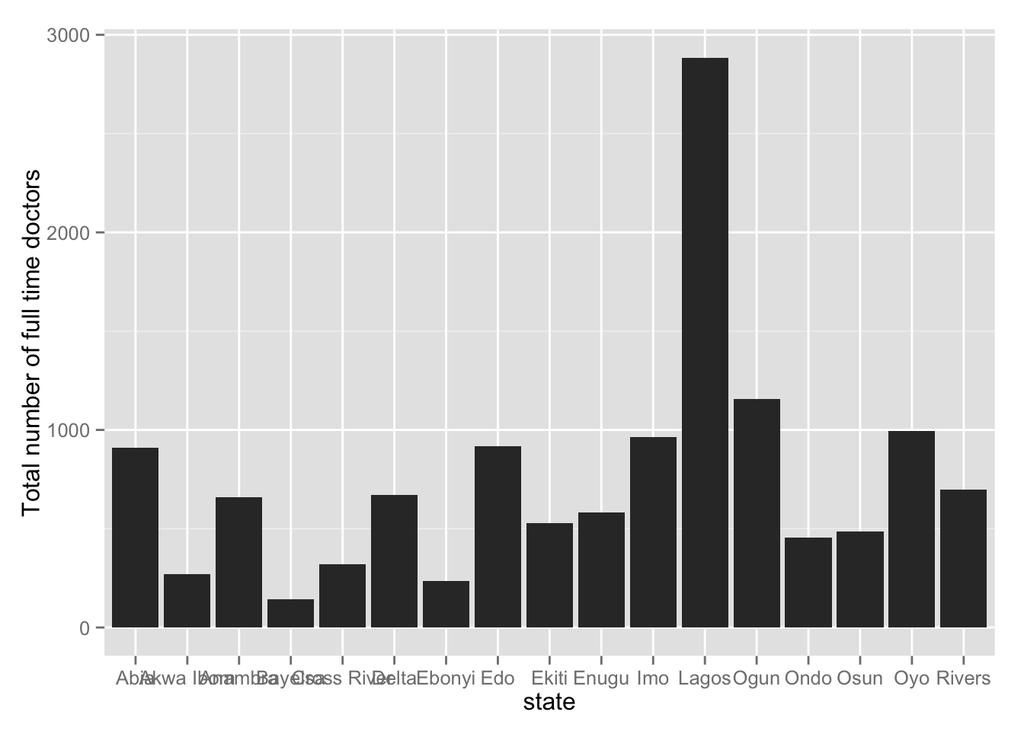

```r
ggplot(data=sort1.state, aes(x=state, y=num_doctors_fulltime)) + ylab("Total number of full time doctors") + geom_bar(stat="identity")
```

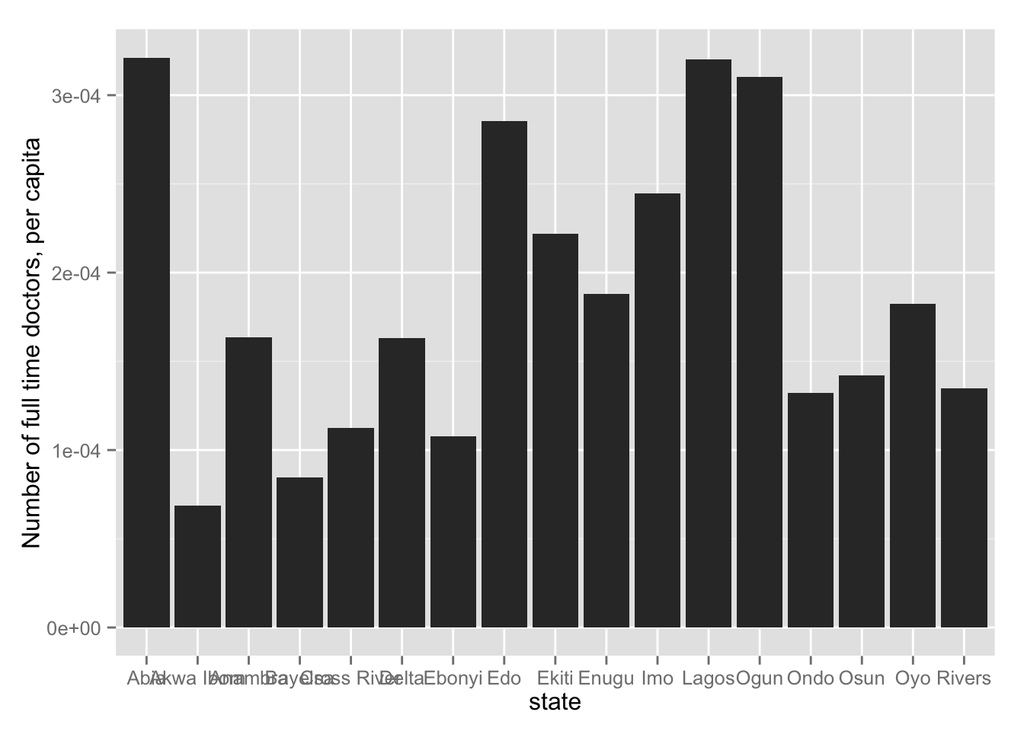

```r
ggplot(data=sort1.state, aes(x=state, y=doctors_pp)) + ylab("Number of full time doctors, per capita") + geom_bar(stat="identity")
```

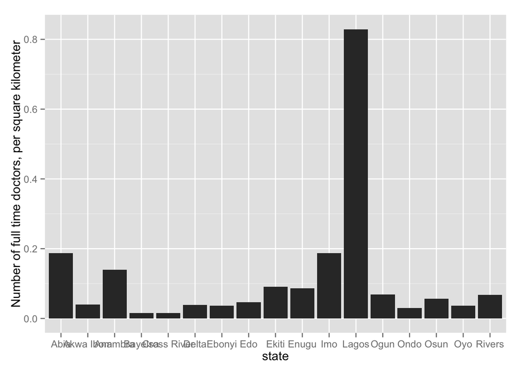

```r
ggplot(data=sort1.state, aes(x=state, y=doctors_psk)) + ylab("Number of full time doctors, per square kilometer") + geom_bar(stat="identity")
```